# Estudio de la Relación Entre los Precios de Vivienda y sus Características de Propiedad Durante el Año 2019 en Lima

07 de Julio del 2023

## 1. **INTRODUCCIÓN**

#### 1.1. **RELEVANCIA:**

El estudio de la relación entre los precios de las viviendas y sus características en Lima durante el año 2019 es de suma importancia para el mercado inmobiliario y la toma de decisiones. Comprender cómo diversos atributos afectan el valor de una vivienda proporciona información valiosa para evaluar su precio y desarrollar estrategias de inversión. Este estudio permite identificar tendencias y patrones, así como entender cómo factores como la ubicación, el tamaño, la antigüedad y los servicios influyen en los precios. Estos conocimientos resultan fundamentales para la implementación de políticas públicas, la planificación urbana y la toma de decisiones financieras relacionadas con bienes raíces.

#### 1.2. **OBJETIVO:**

Analizar la relación entre los precios de vivienda y sus características de propiedad durante el año 2019 en Lima, con el fin de comprender los factores que influyen en la valoración de las propiedades en el mercado inmobiliario de la ciudad.

#### 1.2.1. **OBJETIVOS ESPECÍFICOS:**

- Identificar las principales características de propiedad que están asociadas con precios más altos de vivienda en Lima durante el año 2019.
- Determinar si el número de dormitorios y el sector tienen una influencia conjunta en el precio y valoración de las viviendas en Lima. Se buscará identificar si la combinación de un mayor número de dormitorios y estar ubicado en un sector exclusivo tiene un efecto multiplicador en los precios y valoraciones de las viviendas.
- Analizar la variación de los precios de vivienda entre diferentes distritos de Lima durante el año 2019 y determinar si existen factores geográficos, como la ubicación, que explique estas diferencias.

## 2. **MODO DE ORGANIZACIÓN**

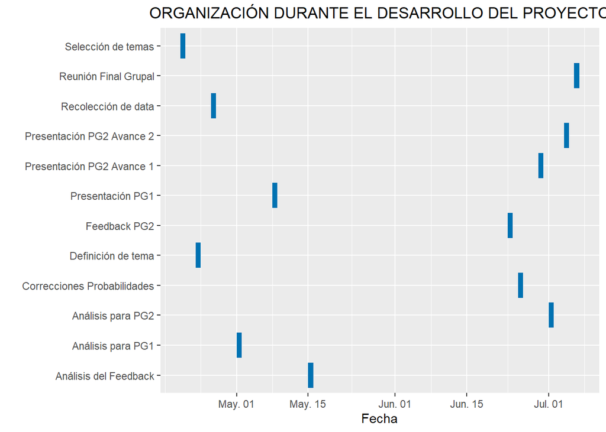

## 3. **DATOS**

#### 3.1. **RECOLECCIÓN DE DATOS**

Los datos utilizados en este estudio fueron extraídos de una base de datos obtenida de la página Urbania.com, correspondiente al año 2019 en Lima, Perú. Esta base de datos ofrece información detallada sobre los precios de vivienda y diversas características de propiedad. Para acceder a la fuente original de los datos, se puede seguir el enlace proporcionado en Kaggle (https://www.kaggle.com/datasets/pbenavides/house-pricing-lima-peru?resource=download).

#### 3.2. **POBLACIÓN**

El estudio se centra en todas las viviendas de Lima, especialmente en Lima Metropolitana, el principal centro urbano y económico del país. Esto proporciona una visión completa de los precios de vivienda y sus características en un entorno urbano y dinámico. Lima abarca una amplia y diversa área geográfica con diversos precios y atributos de propiedad, y cuenta con numerosas transacciones inmobiliarias y opciones de vivienda.

#### 3.3. **MUESTRA**

La base de datos utilizada en este estudio proviene de las viviendas publicadas en la página Urbania.com. La base de datos consta de 7663 filas y 91 columnas, lo que proporciona una gran cantidad de información para analizar. Sin embargo, es importante tener en cuenta que la base de datos puede contener valores nulos, por lo que será necesario realizar una limpieza de datos antes de llevar a cabo el análisis. Esto asegurará que los resultados obtenidos sean confiables y precisos.

#### 3.4. **MUESTREO**

Para llevar a cabo el muestreo de nuestro estudio, se utilizó un instrumento de recolección basado en un código de Python. Este código fue diseñado de manera que pudiera aprovechar métodos avanzados como Machine Learning, Web-Scraping y Programación Orientada a Objetos (POO) para cumplir con su función de manera eficiente y precisa. Los detalles técnicos y una descripción exhaustiva del código utilizado se encuentran disponibles en el siguiente enlace:(https://github.com/PBenavides/Automated-Valuation-Model-Lima)

#### 3.5. **VARIABLES**

| Variable | Tipo | Descripción |
| --- | --- | --- |
| Precio | Numérica/Continua | Precio en soles |
| Dormitorios | Categórica/Ordinal | Cantidad de dormitorios |
| Antigüedad | Numérica/Continua | Años de antigüedad |
| Luminosidad | Categórica/Nominal | Que tan luminoso es |
| Tipo | Categórica/Nominal | Tipo de inmueble |
| Área_total_m2 | Numérica/Continua | Área total |
| Área_constr_m2 | Numérica/Continua | Área total construida |
| NroBanios | Numérica/Continua | Cantidad de baños |
| Estado de Inmueble | Categórica/Nominal | Estado de cuidado en que se encuentra el inmueble |
| Distrito | Categórica/Nominal | Distrito de Lima en que se ubica |
| Cocheras | Numérica/Discreta | Cantidad de cocheras |
| Uso_profesional | Categórica/Nominal | ¿Se le puede dar un uso tipo profesional? |
| Uso_comercial | Categórica/Nominal | ¿Se le puede dar un uso tipo comercial? |
| Nro_pisos | Numérica/Discreta | Cantidad de pisos |
| Piscina | Categórica/Nominal | Cantidad de piscinas |
| Amoblado | Categórica/Nominal | ¿Se encuentra amoblado? |

## 4. **ANÁLISIS DESCRIPTIVO**

### 4.1. **ANÁLISIS GENERAL**

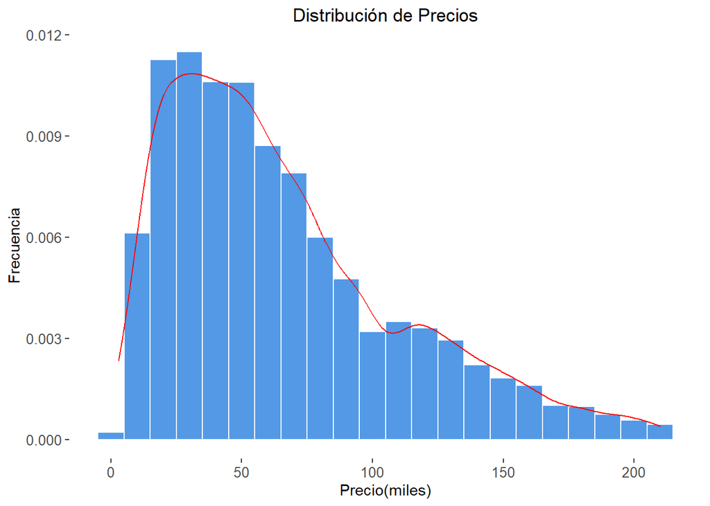

```r
#Histograma PRECIO
ggplot(urbania_data, aes(x = Precio)) +
  geom_histogram(aes(y = ..density..),binwidth = 10, fill = "#5399E6" , color = "white") +
  geom_density(color = "red") +
  labs(title = "Distribución de Precios", x = "Precio(miles)", y = "Frecuencia") +
  theme(plot.title = element_text(hjust = 0.5),
        axis.text = element_text(size = 10),
        panel.background = element_rect(fill = "white"),
        panel.grid.major = element_blank(),
        panel.grid.minor = element_blank(),
        panel.border = element_blank())
```

```r
# Cálculo de la media del precio
mean(urbania_data$Precio)
```

```
## [1] 66.52858
```

```r
# Cálculo de la desviación estándar del precio
sd(urbania_data$Precio)
```

```
## [1] 44.84329
```

```r
# Valor mínimo y máximo del precio
min(urbania_data$Precio)
```

```
## [1] 2.9
```

```r
max(urbania_data$Precio)
```

```
## [1] 210
```

- El histograma de precios representa la distribución de precios de las viviendas en el conjunto de datos. Los precios tienen una media de 66.53 miles de unidades monetarias y una desviación estándar de 44.84. La distribución es sesgada hacia la derecha, lo que indica que la mayoría de las viviendas tienen precios más bajos, mientras que hay algunas viviendas con precios más altos que se consideran valores atípicos. La forma de la distribución sugiere que existe una concentración de viviendas con precios más bajos y una dispersión gradual hacia precios más altos. Esto puede ser útil para comprender la estructura de precios en el mercado inmobiliario y tomar decisiones informadas sobre la compra o venta de viviendas.

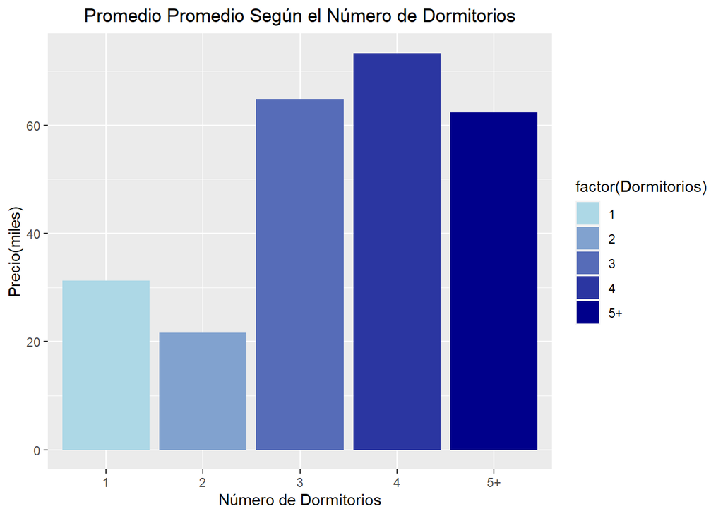

```r
#Gráfico de barras DORMITORIOS-PRECIO
NDor <- urbania_data %>%
  group_by(Dormitorios) %>%
  summarise(PRECIO= mean(Precio))
# Crear la paleta de colores azules
colors <- colorRampPalette(c("lightblue", "darkblue"))(length(levels(factor(NDor$Dormitorios))))
# Crear el gráfico de barras en tonos azules
ggplot(NDor, aes(x = factor(Dormitorios), y = PRECIO, fill = factor(Dormitorios))) +
  geom_bar(stat = "identity") +
  labs(title = "Promedio Promedio Según el Número de Dormitorios", x = "Número de Dormitorios", y = "Precio(miles)") +
  theme(plot.title = element_text(hjust = 0.5)) +
  scale_fill_manual(values = colors)
```

```r
# Cálculo de la variabilidad de precios dentro de cada grupo de dormitorios
# Agrupar los datos por dormitorios y calcular las medidas de dispersión
variability <- urbania_data %>%
  group_by(Dormitorios) %>%
  summarise(
    Rango = max(Precio) - min(Precio),
    Desviacion_estandar = sd(Precio),
    Coeficiente_variacion = sd(Precio) / mean(Precio) * 100
  )
# Mostrar los resultados
variability
```

```
## # A tibble: 5 x 4
##   Dormitorios Rango Desviacion_estandar Coeficiente_variacion
##   <chr>       <dbl>               <dbl>                 <dbl>
## 1 1            159.                42.7                 137.
## 2 2            125.                21.3                  98.2
## 3 3            207.                45.4                  70.0
## 4 4            206.                44.6                  60.8
## 5 5+           206.                43.6                  69.9
```

- El gráfico de barras y los resultados del análisis de variabilidad nos muestran que los precios de las propiedades varían dentro de cada grupo de dormitorios. Los grupos de mayor número de dormitorios tienden a tener una mayor dispersión de precios, mientras que los grupos de menor número de dormitorios muestran una mayor variabilidad en relación con la media. Estos resultados resaltan la importancia de considerar el número de dormitorios al analizar y comparar los precios de las propiedades.

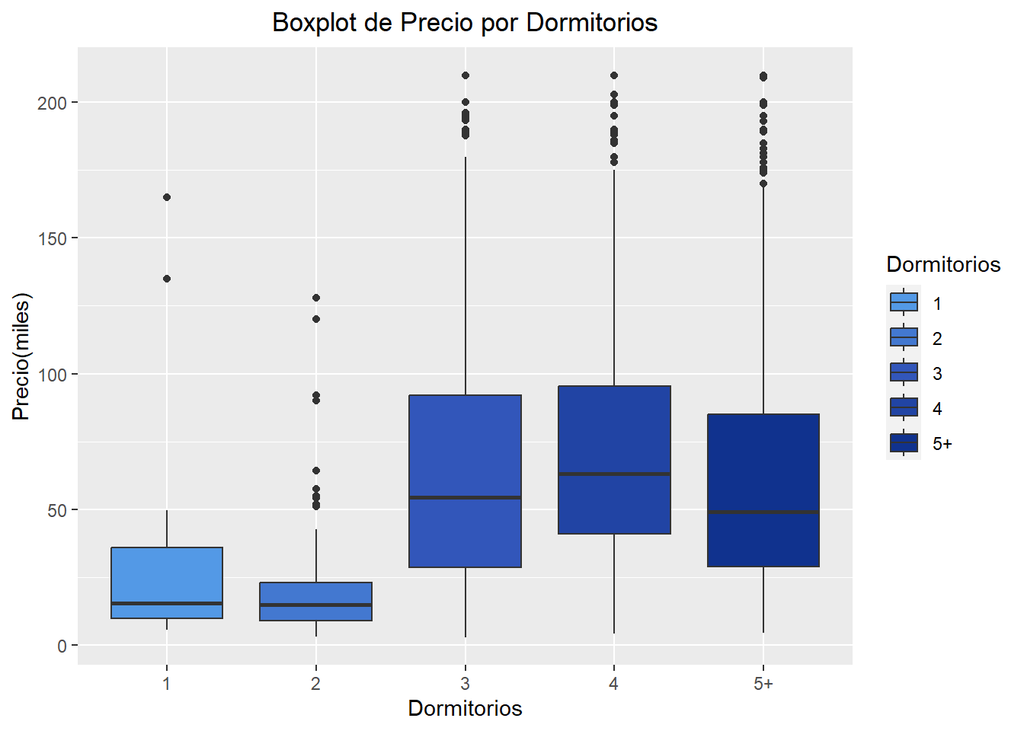

```r
#Box plot indexado PRECIO-DORMITORIOS
ggplot(urbania_data) +
  geom_boxplot(aes(x = Dormitorios, y = Precio, fill = Dormitorios)) +
  labs(title = "Boxplot de Precio por Dormitorios", x = "Dormitorios", y = "Precio(miles)") +
  scale_fill_manual(values = c("#5399E6", "#4378D0", "#3256BA", "#2144A4", "#10328E", "#002076", "#001064")) +
  theme(plot.title = element_text(hjust = 0.5))
```

```r
# Estadísticas descriptivas para cada grupo de dormitorios
stats <- urbania_data %>%
  group_by(Dormitorios) %>%
  summarise(
    Mediana = median(Precio),
    Cuartil_1 = quantile(Precio, 0.25),
    Cuartil_3 = quantile(Precio, 0.75),
    Valor_Minimo = min(Precio),
    Valor_Maximo = max(Precio))
stats
```

```
## # A tibble: 5 x 6
##   Dormitorios Mediana Cuartil_1 Cuartil_3 Valor_Minimo Valor_Maximo
##   <chr>         <dbl>     <dbl>     <dbl>        <dbl>        <dbl>
## 1 1              15.4      9.75      35.8          5.6          165
## 2 2              14.9      9         23            3.1          128
## 3 3              54.5     28.5       92            2.9          210
## 4 4              63       41         95.2          4.2          210
## 5 5+             49       29         85            4.5          210
```

### 4.2. **ANÁLISIS EN LIMA METROPOLITANA**

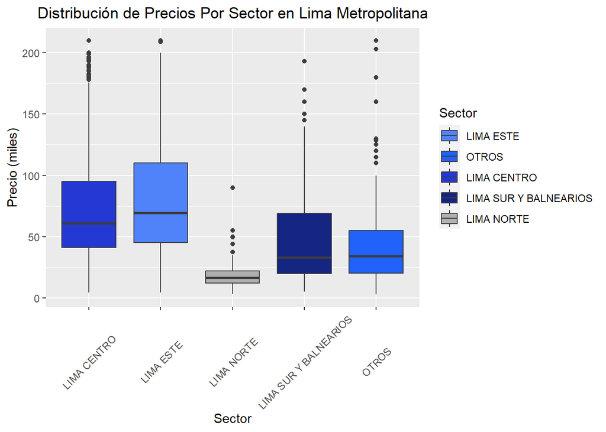

```r
#box plot indexado PRECIO-SECTOR
# Obtener los niveles únicos en la variable "Sector"
sectores <- unique(na.omit(urbania_data$Sector))
# Definir los colores para cada sector
colores <- c("#5083fa", "#2062fa", "#2438d4", "#152582", "#b0b0b0")  # Asegúrate de tener un color para cada sector
ggplot(na.omit(urbania_data), aes(x = Sector, y = Precio, fill = Sector)) +
  geom_boxplot(color = "#3d3d3d") +
  labs(title = "Distribución de Precios Por Sector en Lima Metropolitana", x = "Sector", y = "Precio (miles)") +
  theme(axis.text.x = element_text(angle = 45, vjust = 0.5)) +
  scale_fill_manual(values = colores, breaks = sectores) +
  theme(plot.title = element_text(hjust = 0.5))
```

```r
# Calcular estadísticas descriptivas por sector
stats_por_sector <- urbania_data %>%
  group_by(Sector) %>%
  summarise(
    Media = mean(Precio),
    Mediana = median(Precio),
    Cuartil_1 = quantile(Precio, 0.25),
    Cuartil_3 = quantile(Precio, 0.75),
    Valor_Minimo = min(Precio),
    Valor_Maximo = max(Precio)
  )
stats_por_sector
```

```
## # A tibble: 5 x 7
##   Sector             Media Mediana Cuartil_1 Cuartil_3 Valor_Minimo Valor_Maximo
##   <chr>              <dbl>   <dbl>     <dbl>     <dbl>        <dbl>        <dbl>
## 1 LIMA CENTRO         73.6    61        41          95         4.45          210
## 2 LIMA ESTE           79.6    69.5      45         110         4.5           210
## 3 LIMA NORTE          18.0    16.5      12          22         3.1            90
## 4 LIMA SUR Y BALNEA~  46.5    33        19.4        69         4.95          193
## 5 OTROS               42.5    34        20          55         2.9           210
```

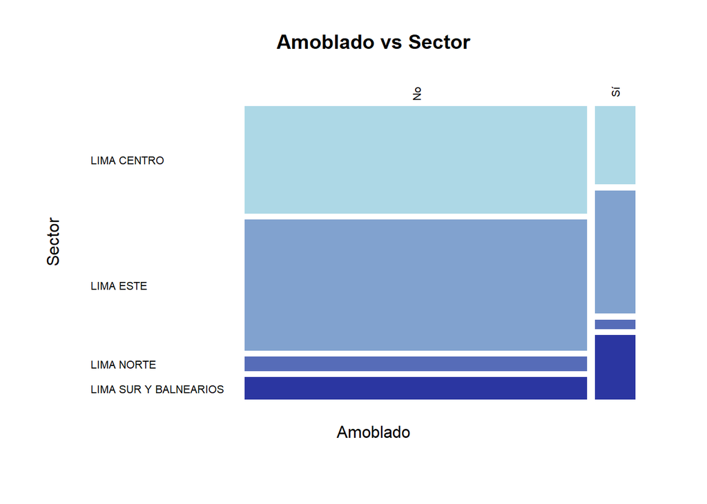

  ```r
  #Mosaico AMOBLADO - SECTOR
  urbania_data$Amoblado[urbania_data$Amoblado == "0"] <- "No"
  urbania_data$Amoblado[urbania_data$Amoblado == "1"] <- "Sí"
  color_palette <- colorRampPalette(c("lightblue", "darkblue"))(length(unique(urbania_data$Sector)))
  mosaicplot(table(urbania_data$Amoblado, urbania_data$Sector)[-2, 1:4], las = 2, color = color_palette, main = "Amoblado vs Sector", xlab = "Amoblado", ylab = "Sector", border = "NA")
  ```

  ```r
  # Filtrar los datos para eliminar filas con valores NA
  filtered_data <- na.omit(urbania_data)
  # Calcular los porcentajes de propiedades con y sin piscina en cada sector
  amoblado_sector <- prop.table(table(filtered_data$Amoblado, filtered_data$Sector), margin = 2)
  # Mostrar los porcentajes en forma de tabla
  amoblado_sector
  ```

  ```
  ##
  ##                LIMA CENTRO  LIMA ESTE LIMA NORTE LIMA SUR Y BALNEARIOS
  ##   No            0.54508566 0.62552301 0.47813411            0.46422018
  ##   NoEspecifica  0.40802525 0.30543933 0.48396501            0.37798165
  ##   Sí            0.04688909 0.06903766 0.03790087            0.15779817
  ##
  ##                     OTROS
  ##   No           0.30321782
  ##   NoEspecifica 0.20420792
  ##   Sí           0.49257426
  ```

- **Lima Centro:** El 54.5% de las propiedades en Lima Centro no están amobladas, mientras que solo el 4.7% están amobladas. Esto indica que la mayoría de las propiedades en esta zona no se ofrecen con mobiliario.
- **Lima Este:** En Lima Este, el 62.5% de las propiedades no están amobladas, mientras que solo el 6.9% están amobladas. Al igual que en Lima Centro, la mayoría de las propiedades en esta zona no se ofrecen con mobiliario.
- **Lima Norte:** En Lima Norte, el 47.8% de las propiedades no están amobladas, mientras que solo el 3.8% están amobladas. Nuevamente, la mayoría de las propiedades en esta zona no se ofrecen con mobiliario.
- **Lima Sur y Balnearios:** En esta zona, el 46.4% de las propiedades no están amobladas, mientras que el 15.8% están amobladas. Existe una proporción significativa de propiedades amobladas en comparación con otras áreas.

## 5. **SELECCIÓN DE VARIABLES**

Nuestro estudio se centra en identificar las características más valiosas de un inmueble. Para lograrlo, hemos seleccionado variables que consideramos fundamentales en este análisis. Las variables elegidas son:

- **Número de dormitorios:** El número de dormitorios es un factor relevante en la evaluación de un inmueble, ya que tiene un impacto directo en su funcionalidad y capacidad de alojamiento. Este dato proporciona información sobre el tamaño y la comodidad de la vivienda, lo cual puede influir significativamente en su valor y demanda.
- **Sector:** El sector o ubicación del inmueble también es una variable crucial, ya que determina su proximidad a servicios, transporte, áreas verdes, centros comerciales y otros elementos clave. La ubicación puede influir en el precio de un inmueble, siendo determinante en la toma de decisiones de los compradores y en la apreciación futura del valor de la propiedad.

Estas dos variables nos permitirán obtener información valiosa para realizar análisis y conclusiones relevantes en nuestro proyecto. Al considerar el número de dormitorios y el sector de un inmueble, podemos examinar cómo influyen en su precio y valoración, y entender qué características son más apreciadas por los potenciales compradores o inversores. Esto nos ayudará a proporcionar recomendaciones y asesoramiento sólido basado en los resultados obtenidos en nuestro estudio.

## 6. **ANÁLISIS PROBABILÍSTICO**

### **6.1 PROBABILIDAD EMPÍRICA**

#### **6.1.1 EXPERIMENTO 1 - DORMITORIOS**

Un agente inmobiliario revisa el catálogo de propiedades de Urbania para agendar una cita y selecciona un inmueble al azar.

*Espacio Muestral:* Para nuestra variable, el espacio muestral estará definido de la siguiente forma.
$$Ω = \{1;2;3;4;5+\}$$
*Eventos:*

- **A1:** Seleccionar un inmueble con 1 dormitorio
- **A2:** Seleccionar un inmueble con 2 dormitorios
- **A3:** Seleccionar un inmueble con 3 dormitorios
- **A4:** Seleccionar un inmueble con 4 dormitorios
- **A5:** Seleccionar un inmueble con 5+ dormitorios

Y la función de probabilidad definida de la siguiente manera:

$$P(A) = \frac{||A||}{||Ω||}$$
Para el caso de dormitorios

```r
table(urbania_data$Dormitorios)/length(urbania_data$Dormitorios)*100
```

```
##
##          1          2          3          4         5+
##  0.3129401  1.7681114 24.1433266 39.8685652 33.9070568
```

*Probabilidad de Eventos:*

- **P(A1):** 0.31%
- **P(A2):** 1.77%
- **P(A3):** 24.14%
- **P(A4):** 39.87%
- **P(A5):** 33.91%

#### **6.1.2 EXPERIMENTO 2 - SECTOR**

Una persona que se dedica al negocio de bienes raíces y tiene propiedades en todo Lima, selecciona un sector para la compra de su próxima propiedad.

*Espacio Muestral:* Para nuestra variable, el espacio muestral estará definido de la siguiente forma.
$$Ω = \{Lima Centro; Lima Norte ; Lima Este ;
Lima Sur y Balnearios; Otros\}$$
Y la función de probabilidad definida de la siguiente manera:

$$P(A) = \frac{||A||}{||Ω||}$$
Para el caso de sectores

*Eventos:*

- **S1:** Seleccionar una propiedad de Lima Centro
- **S2:** Seleccionar una propiedad de Lima Norte
- **S3:** Seleccionar una propiedad de Lima Este
- **S4:** Seleccionar una propiedad de Lima Sur y Balnearios
- **S5:** Seleccionar una propiedad de Otro Sector

```r
table(urbania_data$Sector)/length(urbania_data$Sector)*100
```

```
##
##           LIMA CENTRO             LIMA ESTE            LIMA NORTE
##             35.549992             37.584103              5.476451
## LIMA SUR Y BALNEARIOS                 OTROS
##              8.746675             12.642779
```

**COMENTARIO:** Hay mayor probabilidad de que el inmueble escogido por la persona sea del sector Lima Este.

### **6.2 PROBABILIDAD CONDICIONAL**

**DESCRIPCIÓN:**

Para esta parte, escogeremos 2 pares de eventos, uno donde exista una relación entre ambas variables, y otro donde no exista. Para esto seguiremos el siguiente proceso: - Tomaremos a la variable **Sector** y la variable **Precio** para determinar si existe o no una relación.

*Cuantiles y Etiquetas*

- El cuantil de 0-20% se etiqueta como “Muy Bajo”.
- El cuantil de 20%-40% se etiqueta como “Bajo”.
- El cuantil de 40%-60% se etiqueta como “Medio”.
- El cuantil de 60%-80% se etiqueta como “Alto”.
- El cuantil de 80% a 100% se etiqueta como “Muy Alto”.

```r
percentiles <- quantile(urbania_data$Precio, probs = c(0.2,0.4,0.6,0.8))
urbania_data$Clasificacion <- cut(urbania_data$Precio,
                                     breaks = c(-Inf, percentiles[1], percentiles[2],percentiles[3],percentiles[4], Inf),
                                     labels = c("Muy Bajo", "Bajo", "Medio", "Alto", "Muy Alto"),
                                     include.lowest = TRUE)
```

- Verificaremos la existencia de la dependencia planteando nuestra hipótesis nula, es decir, asumimos que las variables sector y clasificación no tienen relación.
- Usaremos la prueba de chi-cuadrado porque estamos trabajando con dos variables categóricas, utiliza una medida de discrepancia entre las frecuencias observadas y las frecuencias esperadas bajo la hipótesis nula de independencia.

```r
# Crear una tabla de contingencia entre las dos variables
Clas_Sec <- table(urbania_data$Clasificacion, urbania_data$Sector)
Clas_Sec
```

```
##
##            LIMA CENTRO LIMA ESTE LIMA NORTE LIMA SUR Y BALNEARIOS OTROS
##   Muy Bajo         197       244        308                   243   291
##   Bajo             527       379         35                    91   268
##   Medio            546       536          6                    77   108
##   Alto             509       551          1                   104   110
##   Muy Alto         493       692          0                    44    31
```

```r
# Realizar la prueba de chi-cuadrado
chi2_result <- chisq.test(Clas_Sec)
# Obtener el p-value de la prueba de chi-cuadrado
p_value <- chi2_result$p.value
# Imprimir el p-value
cat("El valor de p es:", p_value, "\n")
```

```
## El valor de p es: 0
```

#### **6.2.1 EVENTO 1**

- **A:** Seleccionamos un inmueble con precio “Muy alto”
- **B:** Seleccionamos un inmueble en el sector “Lima_Centro”

$$P(A\cap B) = P(A)* P(B)$$

```r
n <- nrow(urbania_data)
pAyB <- filter(urbania_data, Clasificacion == "Muy Alto" & Sector == "LIMA CENTRO") %>% nrow()
pA <- filter(urbania_data, Clasificacion == "Muy Alto")  %>% nrow()
pB <- filter(urbania_data, Sector == "LIMA CENTRO") %>% nrow()
pA_B <- pAyB/n
pB_A <- (pA/n)*(pB/n)
pA_B
```

```
## [1] 0.07713973
```

```r
pB_A
```

```
## [1] 0.07008761
```

Notamos que si fueran realmente independientes, entonces se cumple que:

- *Ejemplo 01:* ¿Cuál es la probabilidad que una vivienda sea de Precio muy Alto dado que pertenece al sector LIMA CENTRO?

```r
round(pA / n,2)
```

```
## [1] 0.2
```

- *Ejemplo 02:* ¿Cuál es la probabilidad que pertenezca al sector LIMA CENTRO dado que el precio sea de Precio muy Alto?

```r
round(pB / n,2)
```

```
## [1] 0.36
```

#### **6.2.2 EVENTO 2**

```r
table(urbania_data$Dormitorios,urbania_data$Clasificacion)
```

```
##
##      Muy Bajo Bajo Medio Alto Muy Alto
##   1        14    3     1    0        2
##   2        92    9     8    2        2
##   3       375  287   288  274      319
##   4       322  460   608  595      563
##   5+      480  541   368  404      374
```

- **Evento A:** Seleccionar del catálogo inmobiliario un inmueble que tiene 4 dormitorios
- **Evento B:** Seleccionar del catálogo inmobiliario un inmueble que tiene el precio muy alto.

```r
Clas_Sec <- table(urbania_data$Clasificacion, urbania_data$Sector)

chi2_result <- chisq.test(Clas_Sec)

p_value <- chi2_result$p.value

print(p_value)
```

```
## [1] 0
```

No cumple la condición, entonces son eventos dependientes, por lo tanto, se puede hallar su probabilidad condicional

```r
pA <- filter(urbania_data, Dormitorios == 4) %>% nrow() / n
pB <- filter(urbania_data, Clasificacion == "Muy Alto") %>% nrow() / n
pAyB <- filter(urbania_data, Clasificacion == "Muy Alto" & Dormitorios == 4) %>% nrow() / n
pA*pB
```

```
## [1] 0.07860177
```

```r
pAyB
```

```
## [1] 0.08809263
```

- *Ejemplo 03:* ¿Cuál es la probabilidad de que el inmueble tenga 4 dormitorios dado que su precio es muy alto?
  $$P(A/B) = \frac{P(A \cap B)}{P(B)}$$

```r
pA_d_B <- round(pAyB / pB,2)
pA_d_B
```

```
## [1] 0.45
```

La probabilidad de que el inmobiliario tenga 4 dormitorios dato que es un precio alto es 45%

- *Ejemplo 04:* ¿Cuál es la probabilidad de que el precio del inmueble sea muy alto dado que se tiene 4 dormitorios?

$$P(B/A) = \frac{P(B \cap
A)}{P(A)}$$
El problema se plantea con el teorema de Bayes. para la resolución de este problema se hará uso de la probabilidad total y regla de la multiplicación.

regla de la multiplicación:
$$P(B \cap A)
= P(A/B)*P(B)$$
Usamos la propiedad de Probabilidad total para probar nuestras respuesta.

$$P(A) = P(A|B)\cdot P(B)
+P(A|B')\cdot P(B')$$

```r
round(pA_d_B*pB / pA,2)
```

```
## [1] 0.22
```

La probabilidad de que el inmobiliario tenga un precio muy alto dado que el dormitorio es de 4 es 22%

### **6.3 DISTRIBUCIÓN DISCRETA**

#### **6.3.1 DISTRIBUCIÓN BINOMIAL**

$$P(X = k) = \binom{n}{k} \cdot p^k \cdot
(1 - p)^{n-k}$$

¿Cuál es la probabilidad al visitar 20 casas aleatorias visites 12 casas de 2 cocheras?

Variable Aleatoria (X): Número de casas de 2 cocheras que visitas al seleccionar aleatoriamente 20 casas.

```r
prob <- sum(urbania_data$Cocheras==2)/6391
prob
```

```
## [1] 0.3872633
```

**Datos:**

- **x:** 12
- **size:** 20
- **prob =** 0.3872633

```r
dbinom(12,20,prob)
```

```
## [1] 0.02847965
```

[figure not shown]

```r
plot(0:12, dbinom((0:12), 20,prob),  main = "Probabilidad", xlab = "n Intentos Hasta Seleccionar 200 Cocheras de 2 pisos", ylab = "Probabilidad")
```

#### **6.3.2 DISTRIBUCIÓN HIPER GEOMÉTRICA**

$$P(X = k) = \frac{{\binom{K}{k} \binom{N-K}{n-k}}}{{\binom{N}{n}}}$$

- **P(X = k):** Probabilidad de obtener k éxitos en la muestra.
- **K:** Número de éxitos en la población.
- **N:** Tamaño de la población.
- **n:** Tamaño de la muestra.
- **Coeficiente binomial:** $\binom{a}{b}$

¿Cual es la probabilidad de que de una población de 6391 casas se tome una muestra de 500 casas y existan 100 casas de al menos 3 pisos?

**Variable Aleatoria (x):** Número de casas de al menos 3 pisos en una muestra de 500 de una población de 6391 casas.

```r
sum(urbania_data$Nro_pisos >= 3)
```

```
## [1] 2428
```

**Parámetros de la Distribución Hiper Geométrica:**

- **N:** 6391
- **K:** 2428
- **n:** 500

```r
# Parámetros de la distribución hipergeométrica
N <- 6391
K <- 2428
n <- 500
# Cálculo de la probabilidad utilizando dhyper
dhyper(100, K, N-K, n)
```

```
## [1] 1.034697e-19
```

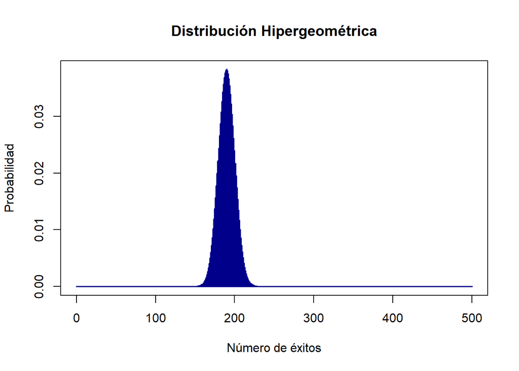

```r
plot(0:n, dhyper(0:n, K, N-K, n), type = "h", lwd = 2, xlab = "Número de éxitos", ylab = "Probabilidad",
     main = "Distribución Hipergeométrica", col = "darkblue")
```

#### **6.3.3 DISTRIBUCIÓN BINOMIAL NEGATIVA**

$$P(X = k) = \binom{k + r - 1}{k} \cdot
p^r \cdot (1 - p)^k$$

```r
sum(urbania_data$Dormitorios == 3)/ 6391
```

```
## [1] 0.2414333
```

**Datos:**

- **x:** 10
- **size:** 5
- **probabilidad:** 0.2414333

Definimos la función:

```r
dnbinom(10,5,0.2414333)
```

```
## [1] 0.05180333
```

Observamos en un gráfico la distribución:

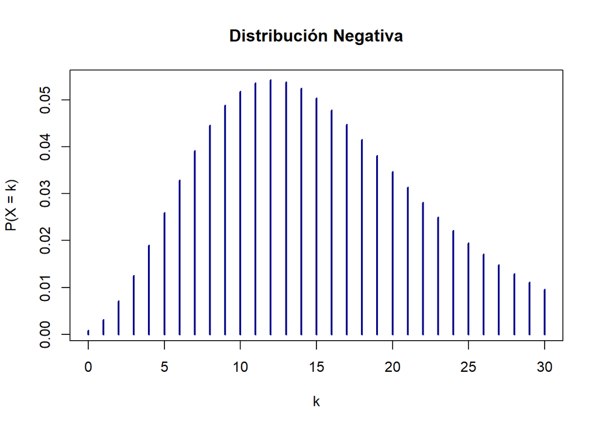

```r
# Parámetros de la distribución negativa
size <- 5
prob <- 0.2414333
# Valores x para el plot
x <- 0:30
# Probabilidades correspondientes a los valores x
probabilities <- dnbinom(x, size, prob)
# Plot de la distribución negativa
plot(x, probabilities, type = "h", lwd = 2, xlab = "k", ylab = "P(X = k)",
     main = "Distribución Negativa", col = "darkblue")
```

### **6.4 DISTRIBUCIÓN CONTINUA**

#### **6.4.1 VARIABLE 1**

- **Variable aleatoria:** Casa dentro del Sector “Lima Centro”
- **Rango:** [0,120]

Primero, para poder determinar observaremos su densidad en un gráfico dado por el Precio.

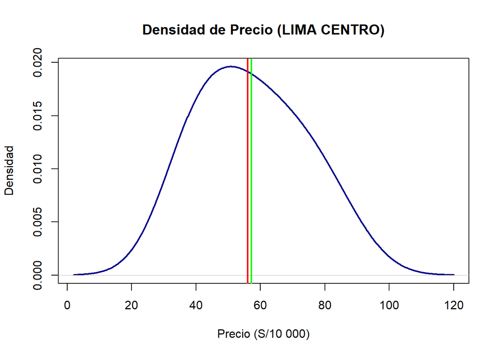

```r
# Variable de interes
x <- subset(urbania_data$Precio,
            urbania_data$Sector == "LIMA CENTRO" &
            urbania_data$Precio <= quantile(urbania_data$Precio, 0.75) &
            urbania_data$Precio >= quantile(urbania_data$Precio, 0.25))
# Estimación de la densidad
density_est <- density(x, bw = 10)
# Ploteo
plot(density_est,
     xlab = "Precio (S/10 000)",
     ylab = "Densidad",
     main = "Densidad de Precio (LIMA CENTRO)",
     col = "darkblue", lwd = 2)

abline(v = median(x), col = "red", lwd = 2)
abline(v = mean(x), col = "green", lwd = 2)
```

Observamos la gráfica de densidad tiene una forma acampanada, procederemos a calcular la varianza y la esperanza de manera teórica para compararla al valor observado.

**Esperanza:**
$$E(X) = \int
x \cdot f(x) \, dx$$

```r
x_interp <- seq(min(density_est$x), max(density_est$x), length.out = 1000)
density_interp <- approx(density_est$x, density_est$y, xout = x_interp)$y
esperanza_aproximada <- integrate(function(x) x * approx(x_interp, density_interp, xout = x)$y, lower = min(x_interp), upper = max(x_interp))$value
esperanza_aproximada
```

```
## [1] 57.30585
```

Ahora calculamos el valor teórica de la varianza para compararlo con el observado

$$\text{Var}(X) = E[(X - \mu)^2$$

```r
mu <- mean(x)
# Cálculo de la varianza teórica
varianza_teorica <- integrate(function(x) (x - mu)^2 * approx(density_est$x, density_est$y, xout = x)$y, lower = min(x), upper = max(x))$value
varianza_teorica
```

```
## [1] 195.7932
```

```r
summary(x)
```

```
##    Min. 1st Qu.  Median    Mean 3rd Qu.    Max.
##   32.00   43.50   56.00   57.26   69.50   90.00
```

```r
var(x)
```

```
## [1] 248.0736
```

```r
lillie.test(x)
```

```
##
##  Lilliefors (Kolmogorov-Smirnov) normality test
##
## data:  x
## D = 0.071465, p-value < 2.2e-16
```

Sacando los parámetros para una distribución normal tenemos lo siguiente:

Al tener definido la función podemos definir una aproximado de cuantas casas existen en el intervalo [40,60] en diez miles.

```r
pnorm(60,mean(x),sd(x))-pnorm(40,mean(x),sd(x))
```

```
## [1] 0.4325299
```

#### **6.4.2 VARIABLE 2**

Primero, para poder determinar observaremos su densidad en un gráfico dado por las áreas.

[figure not shown]

```r
# Variable de interés
x <- subset(urbania_data$Area_total_m2,
            urbania_data$Sector == "LIMA ESTE" &
            urbania_data$Area_total_m2 <= quantile(urbania_data$Area_total_m2, 0.75) &
            urbania_data$Area_total_m2 >= quantile(urbania_data$Area_total_m2, 0.25))
# Estimación de la densidad
density_est <- density(x, bw=65)
#Plotear la densidad
plot(density_est, xlab = "Area (m²)", ylab = "Densidad",
      main = "Densidad de Area (LIMA CENTRO)",
      col = "darkblue", lwd = 2)
abline(v = median(x), col = "red", lwd=2)
abline(v = mean(x), col = "green", lwd=2)
```

Observamos la gráfica de densidad tiene una forma acampanada, procederemos a calcular la varianza y la esperanza de manera teórica para compararla al valor observado.

**Esperanza:**
$$E(X) = \int
x \cdot f(x) \, dx$$

```r
x_interp <- seq(min(density_est$x), max(density_est$x), length.out = 1000)
density_interp <- approx(density_est$x, density_est$y, xout = x_interp)$y
esperanza_aproximada <- integrate(function(x) x * approx(x_interp, density_interp, xout = x)$y, lower = min(x_interp), upper = max(x_interp))$value
esperanza_aproximada
```

```
## [1] 349.6602
```

Ahora calculamos el valor teórica de la varianza para compararlo con el observado

$$\text{Var}(X) = E[(X - \mu)^2$$

```r
mu <- mean(x)
# Cálculo de la varianza teórica
varianza_teorica <- integrate(function(x) (x - mu)^2 * approx(density_est$x, density_est$y, xout = x)$y, lower = min(x), upper = max(x))$value
varianza_teorica
```

```
## [1] 6132.031
```

```r
summary(x)
```

```
##    Min. 1st Qu.  Median    Mean 3rd Qu.    Max.
##   200.0   300.0   320.5   349.4   432.0   528.0
```

```r
var(x)
```

```
## [1] 8506.09
```

```r
lillie.test(x)
```

```
##
##  Lilliefors (Kolmogorov-Smirnov) normality test
##
## data:  x
## D = 0.12776, p-value < 2.2e-16
```

**Experimento 2.1**

Al tener definido la función podemos definir una aproximado de cuantas casas existen en un intervalo. [300,400]

```r
pnorm(400,mean(x),sd(x))-pnorm(300,mean(x),sd(x))
```

```
## [1] 0.4122637
```